# Practical Machine Learning - Course Project

Tomer Einhorn

8/4/2020

## Overview

This document is given as part of the final project in Coursera’s Practical Machine Learning Course, which is part of the Data Science Specialization. The main goal of this project is to predict the manner in which several participant in an experiment perform certain physical exercises as described in the following sections. In terms of the given data sets, the aim of this project is to predict the values of the “classe” variable in the given train set. The machine learning akgorithm described in this document is applied to the given 20 test cases to see how accurate it is.

## Introduction

Using devices such as Jawbone Up, Nike FuelBand, and Fitbit it is now possible to collect a large amount of data about personal activity relatively inexpensively. These type of devices are part of the quantified self movement – a group of enthusiasts who take measurements about themselves regularly to improve their health, to find patterns in their behavior, or because they are tech geeks. One thing that people regularly do is quantify how much of a particular activity they do, but they rarely quantify how well they do it. In this project, your goal will be to use data from accelerometers on the belt, forearm, arm, and dumbell of 6 participants. They were asked to perform barbell lifts correctly and incorrectly in 5 different ways. More information is available from the website here: http://groupware.les.inf.puc-rio.br/har (see the section on the Weight Lifting Exercise Dataset).

## Data Loading and Cleaning

### DataSet Overview

The training data for this project are available here:

https://d396qusza40orc.cloudfront.net/predmachlearn/pml-training.csv

The test data are available here:

https://d396qusza40orc.cloudfront.net/predmachlearn/pml-testing.csv

The data for this project come from this source: http://groupware.les.inf.puc-rio.br/har. If you use the document you create for this class for any purpose please cite them as they have been very generous in allowing their data to be used for this kind of assignment.

## Libraries needed and other setup

```r
set.seed(123456789)
library(caret)
library(rpart)
library(rattle) # needed to plot fancy decision tree
```

## Data uploading

```r
trainUrl <- "https://d396qusza40orc.cloudfront.net/predmachlearn/pml-training.csv"

testUrl <- "https://d396qusza40orc.cloudfront.net/predmachlearn/pml-testing.csv"

download.file(trainUrl, destfile= "./training.csv")
download.file(testUrl, destfile= "./test.csv")
training <- read.csv("training.csv")
testing <- read.csv("test.csv")

inTrain <- createDataPartition(y = training$classe, p=0.6, list=FALSE)
train <- training[inTrain,]
test <- training[-inTrain,]

dim(train)
```

```
[1] 11776   160
```

```r
dim(test)
```

```
[1] 7846  160
```

As we can see, both the train and test data sets contain 160 variables (columns). But, as can be seen by the result of running the following code, a lot of the columns in both the train set and the test set contain a lot of NA values:

```r
trainNAs <- sapply(train, function(x) mean(is.na(x)))
testNAs <- sapply(test, function(x) mean(is.na(x)))
table(trainNAs)
```

```
trainNAs
               0 0.97944972826087
              93               67
```

```r
table(testNAs)
```

```
testNAs
                0 0.979097629365282
               93                67
```

Therefore, we’ll remove from both data sets the columns that contain that little real data:

```r
train <- train[, -trainNAs==FALSE]
test <- test[, -testNAs==FALSE]
```

Now, we have a lot less variables:

```r
dim(train)
```

```
[1] 11776    93
```

```r
dim(test)
```

```
[1] 7846   93
```

We’ll also attempt to remove all columns with zero or near zero variation, as they explain little (or non at all) variance in the “classe” variable value.

```r
nsv <- (nearZeroVar(train))
train <- train[,-nsv]
test <- test[, -nsv]
dim(train)
```

```
[1] 11776    59
```

```r
dim(test)
```

```
[1] 7846   59
```

We’ll also remove the first 6 columns as they are related to identification only:

```r
train <- train[,-(1:6)]
test <- test[, -(1:6)]
dim(train)
```

```
[1] 11776    53
```

```r
dim(test)
```

```
[1] 7846   53
```

By this cleaning process we were able to reduce the number of columns in the training data set from 160 to 53, without losing a lot of valuable information,

## Prediction Models

We will use three predicting models to the train data set, and choose the best performing (in terms of accuracy) to predict the quiz results (the test set). The three models are: 1. Random Forest. 2. Decision Tree. 3. Generalized boosted Regression model. A confusion matrix is plotted for each of the models to visualize each of the models accuracy.

### 1. Random Forest

#### Model Fitting

```r
ControlRandomForest <- trainControl(method="cv", number=3, verboseIter=FALSE)
modFitRF <- train(classe ~ .,data=train,method="rf",trControl=ControlRandomForest)
modFitRF$finalModel
```

```
Call:
 randomForest(x = x, y = y, mtry = param$mtry)
               Type of random forest: classification
                     Number of trees: 500
No. of variables tried at each split: 27

        OOB estimate of  error rate: 0.76%
Confusion matrix:
     A    B    C    D    E class.error
A 3340    6    1    0    1 0.002389486
B   15 2257    7    0    0 0.009653357
C    0   17 2031    6    0 0.011197663
D    0    0   23 1907    0 0.011917098
E    0    2    4    8 2151 0.006466513
```

#### Prediction on test set

```r
RFpredict <- predict(modFitRF, newdata = test)
RFpredictConfMat <- confusionMatrix(factor(RFpredict), factor(test$classe))
RFpredictConfMat
```

```
Confusion Matrix and Statistics

          Reference
Prediction    A    B    C    D    E
         A 2229   20    0    0    0
         B    2 1490   13    2    1
         C    1    8 1352   11    2
         D    0    0    3 1271    3
         E    0    0    0    2 1436

Overall Statistics

               Accuracy : 0.9913
                 95% CI : (0.989, 0.9933)
    No Information Rate : 0.2845
    P-Value [Acc > NIR] : < 2.2e-16

                  Kappa : 0.989

 Mcnemar's Test P-Value : NA

Statistics by Class:

                     Class: A Class: B Class: C Class: D Class: E
Sensitivity            0.9987   0.9816   0.9883   0.9883   0.9958
Specificity            0.9964   0.9972   0.9966   0.9991   0.9997
Pos Pred Value         0.9911   0.9881   0.9840   0.9953   0.9986
Neg Pred Value         0.9995   0.9956   0.9975   0.9977   0.9991
Prevalence             0.2845   0.1935   0.1744   0.1639   0.1838
Detection Rate         0.2841   0.1899   0.1723   0.1620   0.1830
Detection Prevalence   0.2866   0.1922   0.1751   0.1628   0.1833
Balanced Accuracy      0.9975   0.9894   0.9925   0.9937   0.9978
```

Let’s see how accurate this model is:

```r
RFpredictConfMat$overall['Accuracy']
```

```
 Accuracy
0.9913332
```

**So the Random Forest Model results an accuracy of 0.9913!**

#### Plotting matrix results

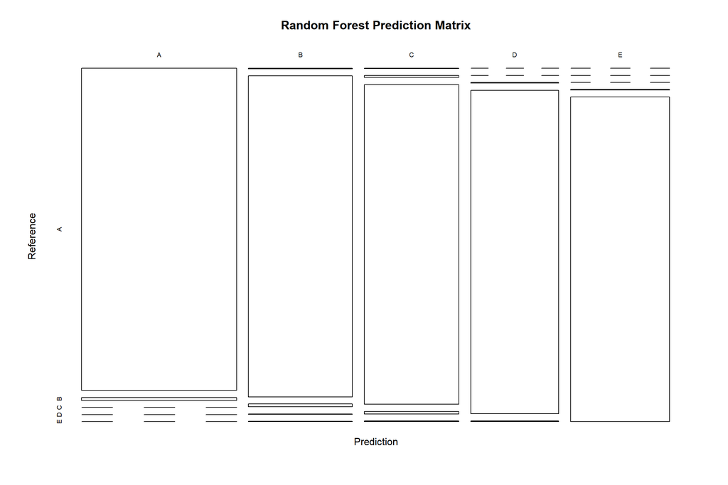

```r
plot(RFpredictConfMat$table, col = RFpredictConfMat$byClass, main = "Random Forest Prediction Matrix")
```

### 2. Decision Tree

#### Model Fitting

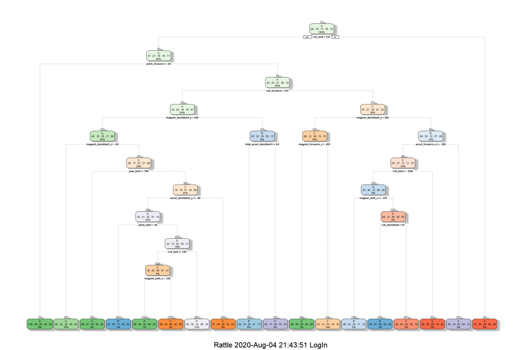

```r
modFitDT <- rpart(classe ~ .,data=train,method="class")
fancyRpartPlot(modFitDT)
```

#### Prediction on testset

```r
DTpredict <- predict(modFitDT, newdata = test, type = "class")
DTpredictConfMat <- confusionMatrix(factor(DTpredict), factor(test$classe))
DTpredictConfMat
```

```
Confusion Matrix and Statistics

          Reference
Prediction    A    B    C    D    E
         A 1842  305   28  127   56
         B   53  813  145   64   99
         C   62  157 1037  185  170
         D  247  234  158  870  211
         E   28    9    0   40  906

Overall Statistics

               Accuracy : 0.6969
                 95% CI : (0.6866, 0.7071)
    No Information Rate : 0.2845
    P-Value [Acc > NIR] : < 2.2e-16

                  Kappa : 0.6167

 Mcnemar's Test P-Value : < 2.2e-16

Statistics by Class:

                     Class: A Class: B Class: C Class: D Class: E
Sensitivity            0.8253   0.5356   0.7580   0.6765   0.6283
Specificity            0.9081   0.9430   0.9114   0.8704   0.9880
Pos Pred Value         0.7812   0.6925   0.6437   0.5058   0.9217
Neg Pred Value         0.9289   0.8943   0.9469   0.9321   0.9219
Prevalence             0.2845   0.1935   0.1744   0.1639   0.1838
Detection Rate         0.2348   0.1036   0.1322   0.1109   0.1155
Detection Prevalence   0.3005   0.1496   0.2053   0.2192   0.1253
Balanced Accuracy      0.8667   0.7393   0.8347   0.7735   0.8081
```

Let’s see how accurate this model is:

```r
DTpredictConfMat$overall['Accuracy']
```

```
 Accuracy
0.6969156
```

#### Plotting matrix results

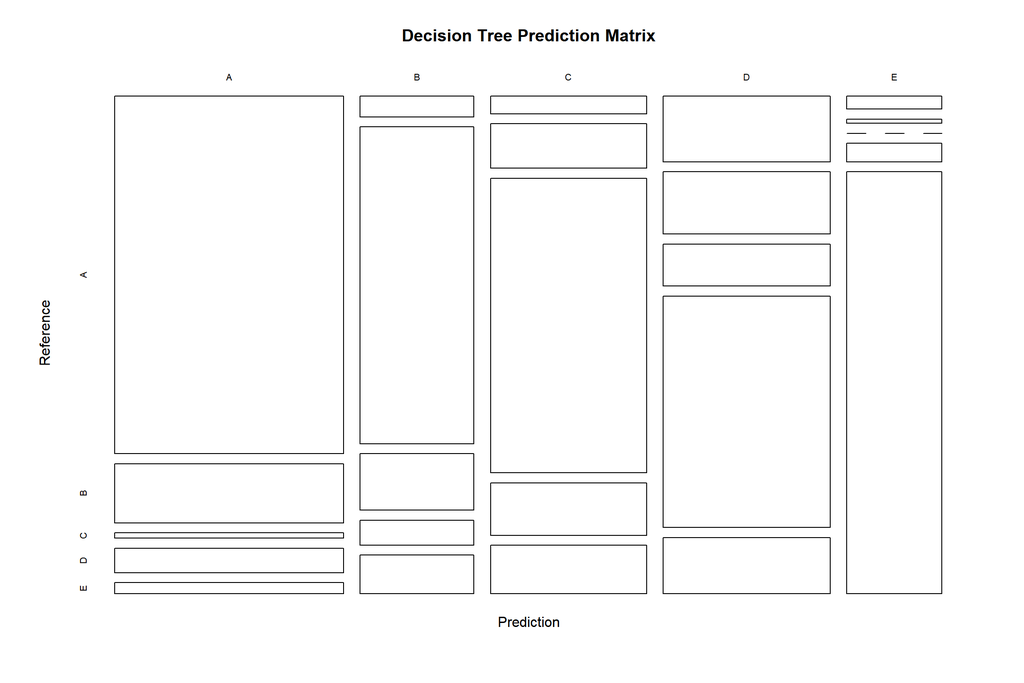

```r
plot(DTpredictConfMat$table, col = DTpredictConfMat$byClass, main = "Decision Tree Prediction Matrix")
```

### 3. Generalized Boosted Regression Model

#### Model Fitting

```r
ControlGBM <- trainControl(method="repeatedcv", number=6, repeats = 1)
modFitGBM <- train(classe ~ .,data=train,method="gbm", trControl=ControlGBM,
                   verbose=FALSE)
modFitGBM$finalModel
```

```
A gradient boosted model with multinomial loss function.
150 iterations were performed.
There were 52 predictors of which 52 had non-zero influence.
```

#### Prediction on testset

```r
GBMpredict <- predict(modFitGBM, newdata = test)
GBMpredictConfMat <- confusionMatrix(factor(GBMpredict), factor(test$classe))
GBMpredictConfMat
```

```
Confusion Matrix and Statistics

          Reference
Prediction    A    B    C    D    E
         A 2190   65    0    3    5
         B   27 1414   40    9   18
         C    7   36 1315   46   14
         D    4    3   11 1218   17
         E    4    0    2   10 1388

Overall Statistics

               Accuracy : 0.9591
                 95% CI : (0.9545, 0.9634)
    No Information Rate : 0.2845
    P-Value [Acc > NIR] : < 2.2e-16

                  Kappa : 0.9482

 Mcnemar's Test P-Value : 2.464e-12

Statistics by Class:

                     Class: A Class: B Class: C Class: D Class: E
Sensitivity            0.9812   0.9315   0.9613   0.9471   0.9626
Specificity            0.9870   0.9851   0.9841   0.9947   0.9975
Pos Pred Value         0.9677   0.9377   0.9274   0.9721   0.9886
Neg Pred Value         0.9925   0.9836   0.9918   0.9897   0.9916
Prevalence             0.2845   0.1935   0.1744   0.1639   0.1838
Detection Rate         0.2791   0.1802   0.1676   0.1552   0.1769
Detection Prevalence   0.2884   0.1922   0.1807   0.1597   0.1789
Balanced Accuracy      0.9841   0.9583   0.9727   0.9709   0.9800
```

Let’s see how accurate this model is:

```r
GBMpredictConfMat$overall['Accuracy']
```

```
 Accuracy
0.9590874
```

#### Plotting matrix results

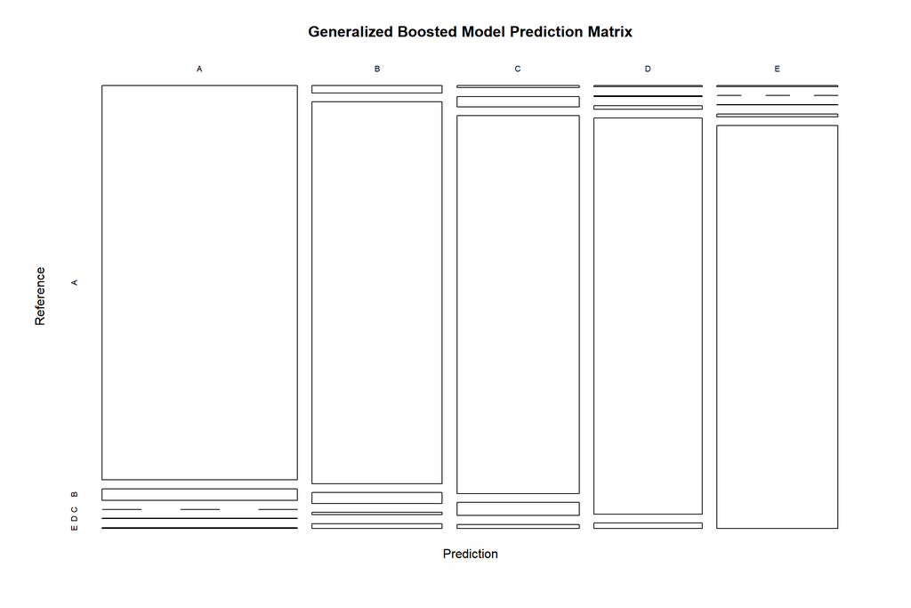

```r
plot(GBMpredictConfMat$table, col = GBMpredictConfMat$byClass,
     main = "Generalized Boosted Model Prediction Matrix")
```

## Final Model Choice and Prediction on Test Set:

To sum up, let’s review the accuracy of the 3 models above:

1. Random Forest: 0.9913.
2. Decision Tree: 0.6969.
3. Generalized Boosted Regression Models: 0.9591

As we can see, Random Forest is the most accurate model out of the three, and therefore it will be applied to predict the 20 observations in the test set (and the quiz):

```r
testingprediction <- predict(modFitRF, newdata=testing)
testingprediction
```

```
 [1] B A B A A E D B A A B C B A E E A B B B
Levels: A B C D E
```